# Homework 1: Principal Component Analysis (PCA) and Multidimensional Scaling (MDS)

Group 13 : Anna Monsó Rodríguez, Walter José Troiani Vargas, Joan Acero Pousa

2024-10-07

0. Import the data set “euroleague_23_24.csv”: the player statistics of four teams taken part in Final Four of Euro League 2023-2024.

```r
rm(list=ls())
euroleague_23_24 <- read.csv2("euroleague_23_24.csv")
```

1. Exploratory data analysis # a) Discard the variable “No” from the data set.

```r
df <- euroleague_23_24[,-1]
```

# b) Split variable “Min” using strsplit() function. Give the name “aux” to the output. The first element of each row will show the minutes that the player played in total. (1p)

```r
min_column = df[,6]
min_column_splited = strsplit(min_column,split=':',fixed=TRUE)
aux <- sapply(min_column_splited, function(x) {
  as.numeric(x[1]) * 60 + as.numeric(x[2]) + as.numeric(x[3]) / 60
})

df<- data.frame(Aux = aux, df[,])

# No acabo de entendre si un cop afegit la columna aux s'ha de borra la columna antiga de MIN
```

# c) Add a numerical variable to the data set named “Min 2” which shows on average how many minutes each player played in the game.

```r
games_played <- df[,5]
min2 <- aux/games_played
df <- data.frame(df[,1], Min2 = min2, df[,-1])
```

# d) Check the structure of the data and assign correct type to each variable considering whether it is a categorical or numerical variable.

```r
str(df)
```

```
## 'data.frame':    64 obs. of  23 variables:
##  $ df...1. : num  356 896 638 145 456 ...
##  $ Min2    : num  11.9 32 79.8 20.7 19 ...
##  $ TEAM    : chr  "PANATHINAIKOS" "PANATHINAIKOS" "PANATHINAIKOS" "PANATHINAIKOS" ...
##  $ PLAYER  : chr  "PANAGIOTIS KALAITZAKIS " "LUCA VILDOZA" "KYLE GUY" "DIMITRIS MORAITIS" ...
##  $ POSITION: chr  "Guard" "Guard" "Guard" "Guard" ...
##  $ GP      : int  30 28 8 7 24 34 1 16 41 35 ...
##  $ GS      : int  0 5 1 0 9 15 0 4 34 27 ...
##  $ Min     : chr  "5:56:00" "14:56:00" "10:38:00" "2:25:00" ...
##  $ PTS     : num  2.1 5.7 4 1.6 2.8 12.7 3 5.6 8.6 16 ...
##  $ X2P.    : num  69 42 71.4 25 62.9 59.1 0 46.9 49.7 46.6 ...
##  $ X3P.    : num  25 36.6 31.6 75 11.1 41.5 100 51.6 41.6 41 ...
##  $ FT.     : num  100 76.2 80 0 70 85.3 0 80 86.1 95.9 ...
##  $ OR      : num  0.3 0.4 0 0 0.6 0.6 0 0.4 0.5 0.4 ...
##  $ DR      : num  0.6 1.1 0.9 0.3 0.8 2.6 0 1.6 1.8 2.3 ...
##  $ TR      : num  0.9 1.5 0.9 0.3 1.3 3.2 0 2 2.3 2.7 ...
##  $ AST     : num  0.2 1.5 0.8 0.7 0.3 5.6 1 0.7 3.5 3 ...
##  $ STL     : num  0.2 0.6 0.2 0.3 0.2 0.8 0 0.2 1.5 0.9 ...
##  $ TO      : num  0.2 1 1 0.3 0.3 2.4 0 0.4 1.1 3.1 ...
##  $ BLK     : num  0 0 0.1 0 0.4 0 0 0.2 0.1 0.1 ...
##  $ BLKA    : num  0 0.2 0 0.1 0.1 0.4 0 0.2 0.1 0.8 ...
##  $ FC      : num  0.8 0.8 1.2 0.1 1.5 1.8 0 1.4 2.3 2.2 ...
##  $ FD      : num  0.4 0.6 0.6 0 1.2 3 0 0.9 2.1 2.7 ...
##  $ PIR     : num  2.1 4.6 2.4 1.7 3.1 16.1 3 5.4 10.9 11.7 ...
```

```r
df$TEAM <- as.factor(df$TEAM)
df$PLAYER<- as.factor(df$PLAYER)
df$POSITION <- as.factor(df$POSITION)
df$GP <- as.numeric(df$GP)
df$GS <- as.numeric(df$GS)
df <- df[,-8] # I delete the column of Min with a String format

str(df)
```

```
## 'data.frame':    64 obs. of  22 variables:
##  $ df...1. : num  356 896 638 145 456 ...
##  $ Min2    : num  11.9 32 79.8 20.7 19 ...
##  $ TEAM    : Factor w/ 4 levels "FENERBAHCE","OLYMPIAKOS",..: 3 3 3 3 3 3 3 3 3 3 ...
##  $ PLAYER  : Factor w/ 64 levels "ALBERTO ABALDE",..: 51 36 35 7 3 34 4 24 27 30 ...
##  $ POSITION: Factor w/ 3 levels "Center","Forward",..: 3 3 3 3 2 3 2 2 3 3 ...
##  $ GP      : num  30 28 8 7 24 34 1 16 41 35 ...
##  $ GS      : num  0 5 1 0 9 15 0 4 34 27 ...
##  $ PTS     : num  2.1 5.7 4 1.6 2.8 12.7 3 5.6 8.6 16 ...
##  $ X2P.    : num  69 42 71.4 25 62.9 59.1 0 46.9 49.7 46.6 ...
##  $ X3P.    : num  25 36.6 31.6 75 11.1 41.5 100 51.6 41.6 41 ...
##  $ FT.     : num  100 76.2 80 0 70 85.3 0 80 86.1 95.9 ...
##  $ OR      : num  0.3 0.4 0 0 0.6 0.6 0 0.4 0.5 0.4 ...
##  $ DR      : num  0.6 1.1 0.9 0.3 0.8 2.6 0 1.6 1.8 2.3 ...
##  $ TR      : num  0.9 1.5 0.9 0.3 1.3 3.2 0 2 2.3 2.7 ...
##  $ AST     : num  0.2 1.5 0.8 0.7 0.3 5.6 1 0.7 3.5 3 ...
##  $ STL     : num  0.2 0.6 0.2 0.3 0.2 0.8 0 0.2 1.5 0.9 ...
##  $ TO      : num  0.2 1 1 0.3 0.3 2.4 0 0.4 1.1 3.1 ...
##  $ BLK     : num  0 0 0.1 0 0.4 0 0 0.2 0.1 0.1 ...
##  $ BLKA    : num  0 0.2 0 0.1 0.1 0.4 0 0.2 0.1 0.8 ...
##  $ FC      : num  0.8 0.8 1.2 0.1 1.5 1.8 0 1.4 2.3 2.2 ...
##  $ FD      : num  0.4 0.6 0.6 0 1.2 3 0 0.9 2.1 2.7 ...
##  $ PIR     : num  2.1 4.6 2.4 1.7 3.1 16.1 3 5.4 10.9 11.7 ...
```

2. Application of PCA

# a) Apply PCA on all the scaled numerical variables in the data set by using PCA() function in FactoMineR package. Treat the categorical variables and the variable “PIR” as suplemantary variables using arguments quali.sup and quanti.sup correctly. (3p)

```r
library(FactoMineR)
categ_vars <- c("TEAM", "PLAYER", "POSITION")

res_pca <- PCA(df, scale.unit = TRUE, graph=FALSE,
               quali.sup = which(names(df) %in% categ_vars),
               quanti.sup = which(names(df) == "PIR"))
```

# b) How many components should be extracted? Decide on the number of components considering eigenvalues. (3p)

There are 3 main criterions to decide the number of components:

1. The size of the eigenvalues associated with each components (Kaiser rule’s suggests values greater than 1)
2. Percentage of explained variation should be at least from 2/3 (66.7%) to 4/5 (80%).
3. Elbow point in the Scree plot

Conclusions: the 2 first components are the ones which explain the most variability, but to surpass 2/3 of variation explained we would need **3 components** and even up to 4 due to eigenvalue size > 1.

1. Looking at the size of the eigenvalues, the 4th one is the last with a value above 1
2. From the 3th component we get a 69% of variation explained and 74% with 4 components
3. From the scree plot we can see a clear elbow point at just the 2nd point, after that the following components don’t even explain a 10% of the variation.

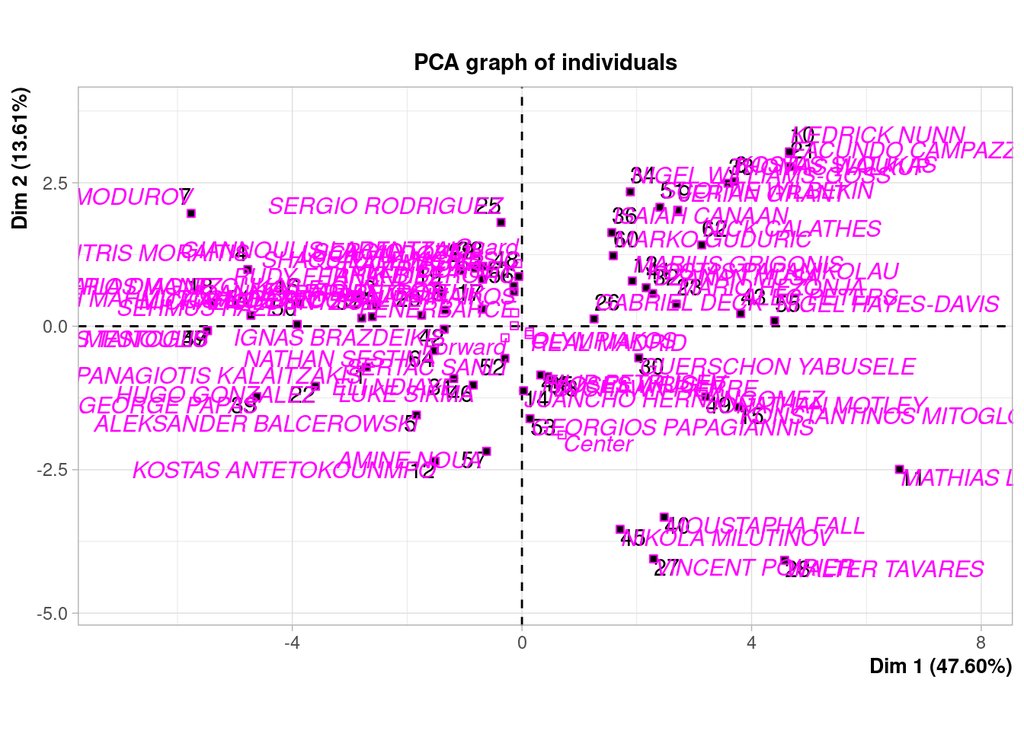

```r
plot(res_pca)
```

```r
#See eigenvalues great than 1
res_pca$eig
```

```
##           eigenvalue percentage of variance cumulative percentage of variance
## comp 1  8.5673841185           47.596578436                          47.59658
## comp 2  2.4504840994           13.613800552                          61.21038
## comp 3  1.4224480739            7.902489300                          69.11287
## comp 4  1.0136902223            5.631612346                          74.74448
## comp 5  0.8235070568            4.575039204                          79.31952
## comp 6  0.7506031080            4.170017267                          83.48954
## comp 7  0.6078112322            3.376729068                          86.86627
## comp 8  0.4733105703            2.629503168                          89.49577
## comp 9  0.4512669327            2.507038515                          92.00281
## comp 10 0.3146126778            1.747848210                          93.75066
## comp 11 0.2991543637            1.661968687                          95.41262
## comp 12 0.2487888219            1.382160122                          96.79478
## comp 13 0.1844412501            1.024673612                          97.81946
## comp 14 0.1570874800            0.872708222                          98.69217
## comp 15 0.1080902612            0.600501451                          99.29267
## comp 16 0.0967095937            0.537275521                          99.82994
## comp 17 0.0301983875            0.167768820                          99.99771
## comp 18 0.0004117499            0.002287499                         100.00000
```

```r
which(res_pca$eig[,1] > 1)
```

```
## comp 1 comp 2 comp 3 comp 4
##      1      2      3      4
```

```r
#How many components are needed for 67%?
which(res_pca$eig[,3] > 67)[1]
```

```
## comp 3
##      3
```

```r
#How many components are needed for 80%?
which(res_pca$eig[,3] > 80)[1]
```

```
## comp 6
##      6
```

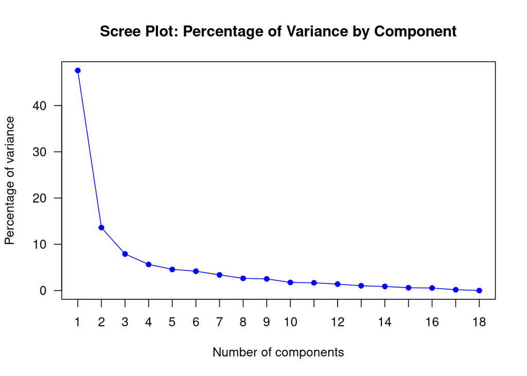

```r
#Compute Scree plot
plot(res_pca$eig[,2], type="o", main="Scree Plot: Percentage of Variance by Component", xlab="Number of components", ylab="Percentage of variance", col="blue", pch=16, xaxt="n", yaxt="n")
axis(1, at=1:length(res_pca$eig[,2]), labels=1:length(res_pca$eig[,2]), las=1)
axis(2, las=1)
```

# c) Interpret the loadings/correlations of variables at each dimension (3p).

Conclusions: Given that the matrices are scaled using the correlation matrix:

- *Dimension 1*: The most correlated variables of the first loading are PTS (Points Score), DR (Defensive Rebounds), GP (Games played), FD (Personal fouls drawn), FC (Personal fouls commited), STL(Steals) TR (Total rebounds), TO (Turnovers), and GS (Games started) primarily. **1st component explains the performance/activity of a given player**

-*Dimension 2*: Here the main variables have negative correlation like BLK (Blocks), OR (Offensive rebounds), TR (Total rebounds), in contrast of positively correlated variables like STL(steals), AST(assists), TO (Turnovers) and X3P(Percentage of 3points). **2nd component likely explains how defensive/offensive a player is, its contrast of defensive/offensive actions**

-*Dimension 3*: The most correlated positive variable is Min2 (Average player time on field) followed by 3 negative ones like FT (Percentage of free throws), X2P (Percentage of two points) and GP (Games played).**3rd dimension shows the playtime vs efficiency of a player**

-*Dimension 4*: By far the most representative variable is X3P (Percentage of 3 points) and more marginally Min2 (Average player time on the field). **4th dimension represents the three-point shooting ability of a player**

```r
loadings <- res_pca$var$coord
dim_id <- 4
sort(loadings[, dim_id])
```

```
##          AST           TO           FD      df...1.         BLKA          STL
## -0.233566011 -0.214321155 -0.192982579 -0.135222264 -0.070483360 -0.044440806
##           GS           FC          BLK         X2P.           GP           OR
## -0.025134951  0.004627085  0.046212737  0.050808439  0.051828478  0.095112567
##          FT.          PTS           TR           DR         Min2         X3P.
##  0.132644308  0.147283882  0.160045702  0.176812908  0.230266652  0.827310860
```

```r
loadings
```

```
##               Dim.1       Dim.2       Dim.3        Dim.4       Dim.5
## df...1.  0.78296465  0.13353571  0.13993621 -0.135222264 -0.11691400
## Min2    -0.10204153  0.17435477  0.71509617  0.230266652  0.60178844
## GP       0.84190065  0.08623200 -0.33089770  0.051828478 -0.15309758
## GS       0.76803377  0.09365341  0.07713733 -0.025134951 -0.10658979
## PTS      0.90426759  0.16821824  0.11352047  0.147283882 -0.02476694
## X2P.     0.44743200 -0.37086102 -0.49874238  0.050808439  0.40903461
## X3P.     0.06506241  0.47165751 -0.04721699  0.827310860 -0.18665539
## FT.      0.59564410  0.08452743 -0.52905257  0.132644308  0.33490209
## OR       0.64056700 -0.66484582  0.16525825  0.095112567 -0.07950360
## DR       0.86741612 -0.25762749  0.12253318  0.176812908 -0.06555810
## TR       0.84077695 -0.42485334  0.14470905  0.160045702 -0.07295877
## AST      0.59875903  0.56929132 -0.02620243 -0.233566011  0.03492712
## STL      0.72329339  0.40375519 -0.09437787 -0.044440806 -0.03457737
## TO       0.81743268  0.33865304  0.12067100 -0.214321155  0.09975894
## BLK      0.35101279 -0.79094278  0.10748967  0.046212737 -0.04715885
## BLKA     0.59743836  0.24442805  0.27951513 -0.070483360 -0.13301185
## FC       0.80822146  0.03442299 -0.12427138  0.004627085  0.22109843
## FD       0.84585817 -0.11573831  0.19938979 -0.192982579  0.02926765
```

# d) Use plot.PCA() function to show correlations between variables and the extracted dimensions. (For the variables you should use the argument choix = “var”). Plot all the extracted dimensions changing argument “axes”.(3p)

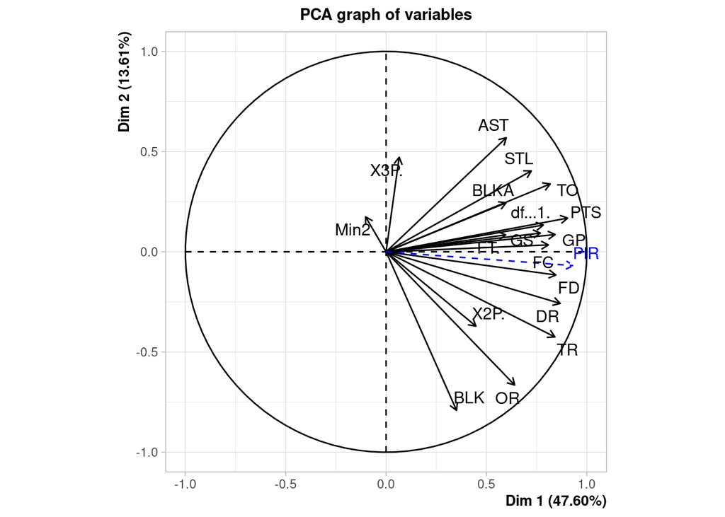

```r
# Dimension 1 vs others
plot.PCA(res_pca, choix="var", axes=c(1, 2), main="Dim 1 vs Dim 2")
```

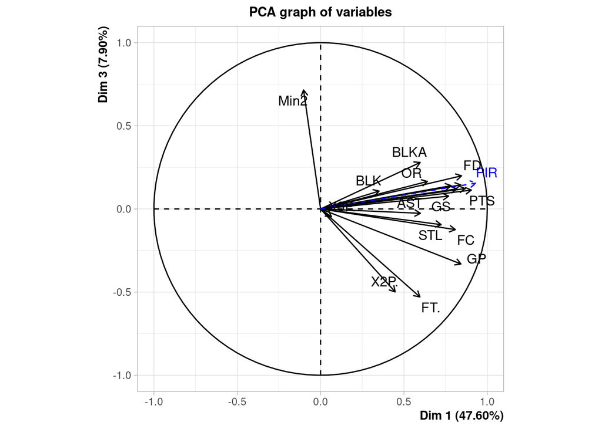

```r
plot.PCA(res_pca, choix="var", axes=c(1, 3), main="Dim 1 vs Dim 3")
```

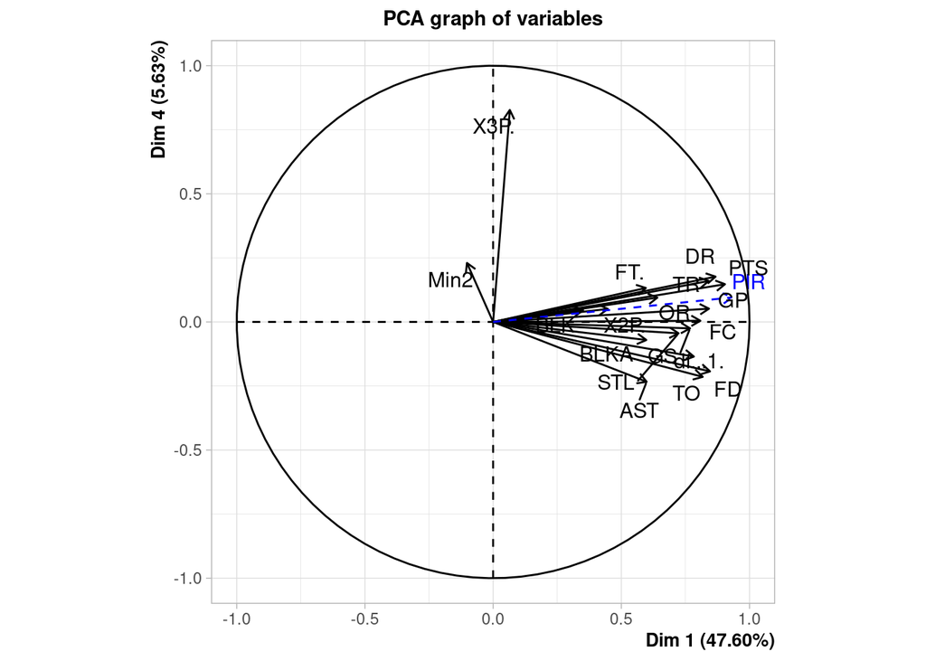

```r
plot.PCA(res_pca, choix="var", axes=c(1, 4), main="Dim 1 vs Dim 4")
```

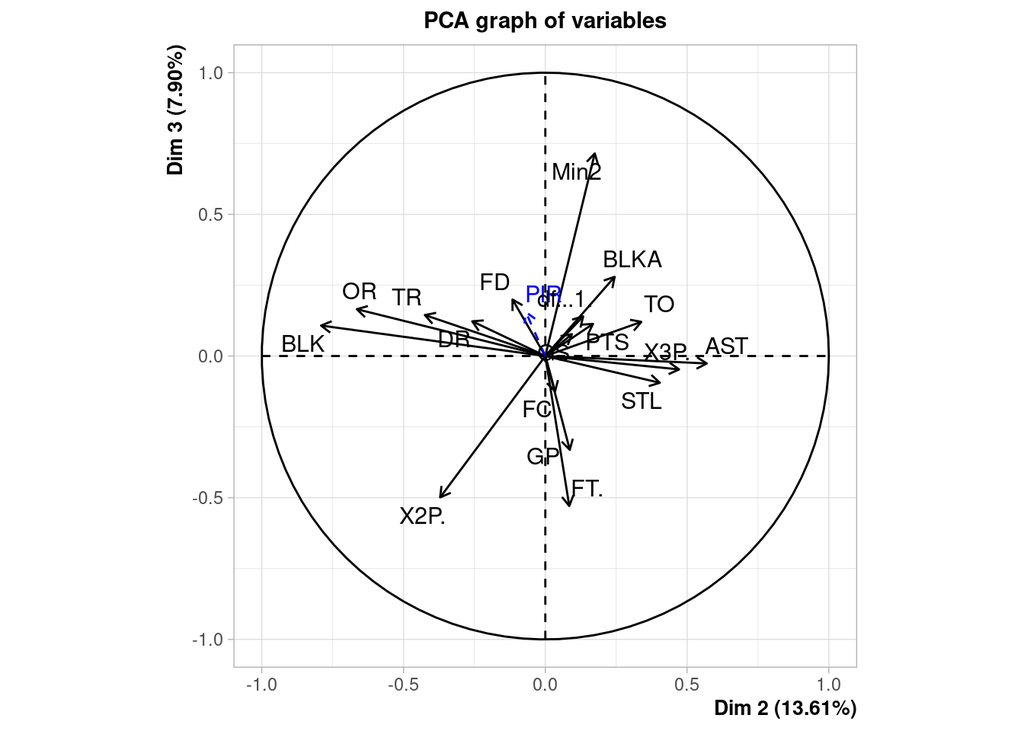

```r
# Plotting Dim 2 vs others (that haven't been plotted yet)
plot.PCA(res_pca, choix="var", axes=c(2, 3), main="Dim 2 vs Dim 3")
```

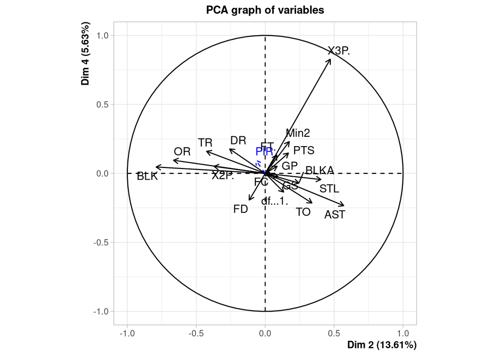

```r
plot.PCA(res_pca, choix="var", axes=c(2, 4), main="Dim 2 vs Dim 4")
```

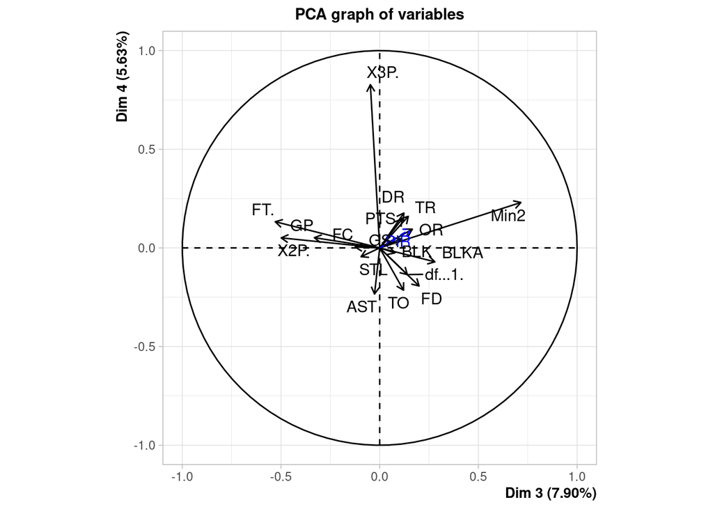

```r
# Dim 3 vs Dim 4
plot.PCA(res_pca, choix="var", axes=c(3, 4), main="Dim 3 vs Dim 4")
```

# e) Interpret variable plots. How can each dimension be named? (5p)

Looking at variable plots, we can extract several conclusions:

- From looking at the plots including dimension 1 we can infer that 1st dimension is **performance**. This is due to the fact that all variables involved in this dimension are directly performance metrics of the players.
- Looking at plots of the 2nd dimension we can infer that is named: **playing style**. This is due to the fact that there are 3 positive important variables (AST, STL, X3P) and 3 negative ones (BLK, OR, TR) that almost cancel each other out in direction and value. To have a broader understanding of the second dimension one should have domain knowledge of basketball itself. Typically **outer** players like guard/wings would score higher on this dimension (They are often the ones which score the most triples and perform the most assistances) and **interior** players such as center/power-forwards which tend to be the more phsyically imposing and defensive players are the ones who perform the most number of blocks and rebounds, then they would score lower.
- Looking at the third dimension we can see that on one side of the spectrum are the average minutes and the other one some performance metrics like GP, FT and X2P. From this inverse proportion between time and metrics we can see a kind of **efficiency** dimension.
- Finally by taking a glance at dimension 4, by far the most representative variable is X3P (Percentage of 3 points) and more marginal variables Min2 (Average player time on the field), PTS… . This 4th dimension is somewhat noisy and should be called **three_point_ability**. However this indicates us that this dimension is similar to variable itself with extra added noise and doesn’t provide much dimensionality reduction to the analysis.

# f) Show individual pilots for the extracted dimensions changing argumennt choix=“ind” in plot.PCA() function. (2p)

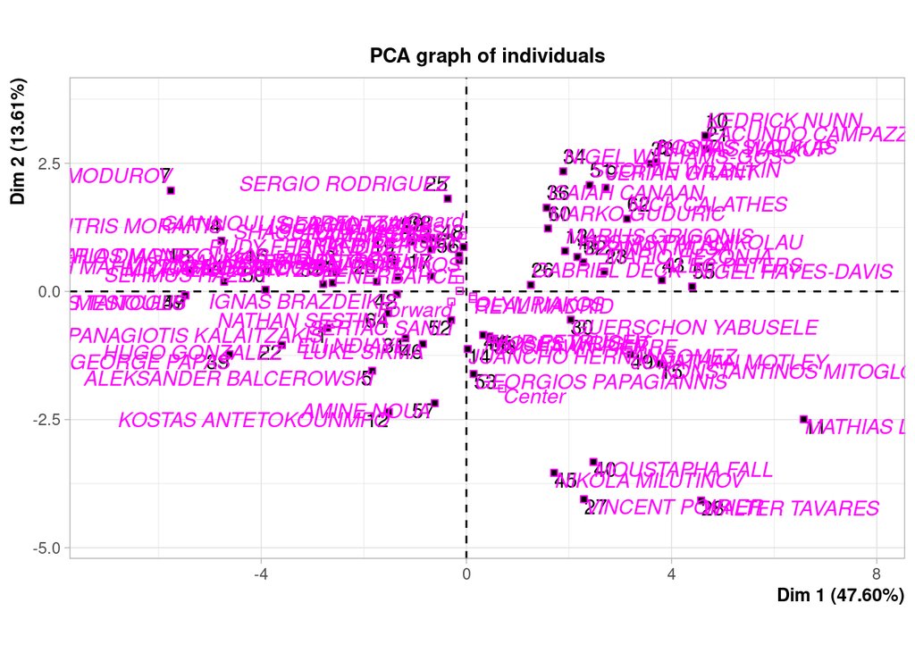

```r
?plot.PCA
# Dimension 1 vs others
plot.PCA(res_pca, choix="ind", axes=c(1, 2), main="Dim 1 vs Dim 2")
```

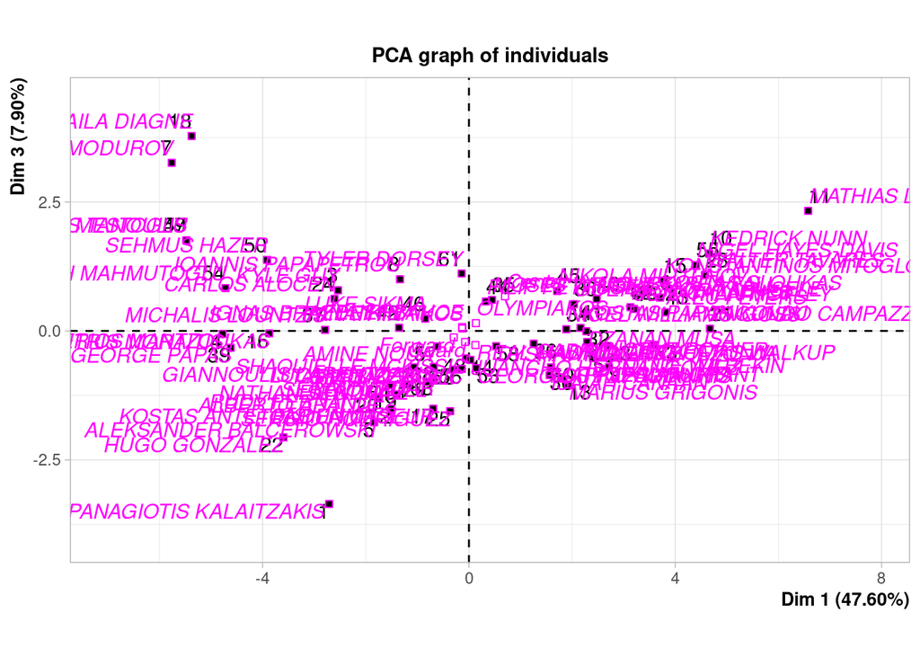

```r
plot.PCA(res_pca, choix="ind", axes=c(1, 3), main="Dim 1 vs Dim 3")
```

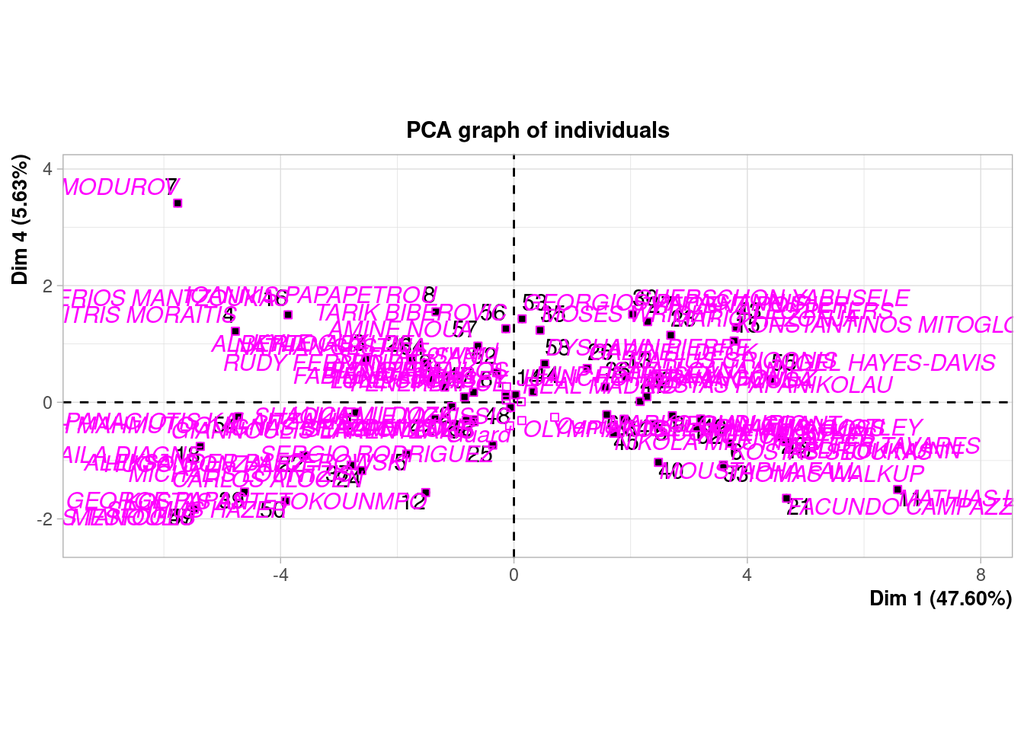

```r
plot.PCA(res_pca, choix="ind", axes=c(1, 4), main="Dim 1 vs Dim 4")
```

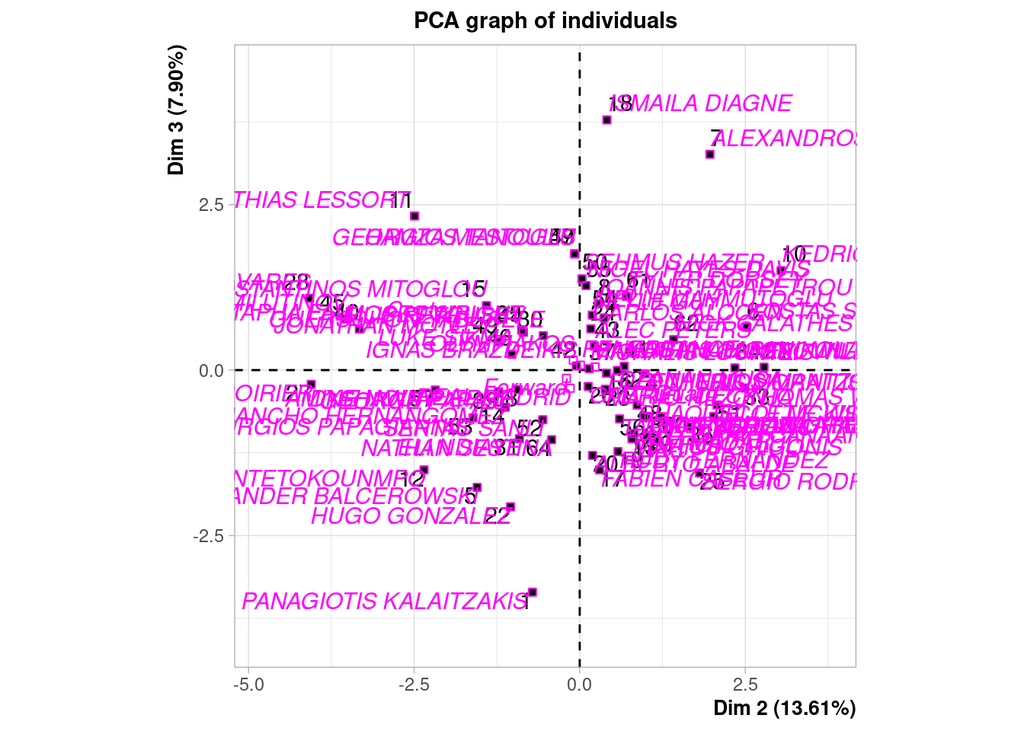

```r
# Plotting Dim 2 vs others (that haven't been plotted yet)
plot.PCA(res_pca, choix="ind", axes=c(2, 3), main="Dim 2 vs Dim 3")
```

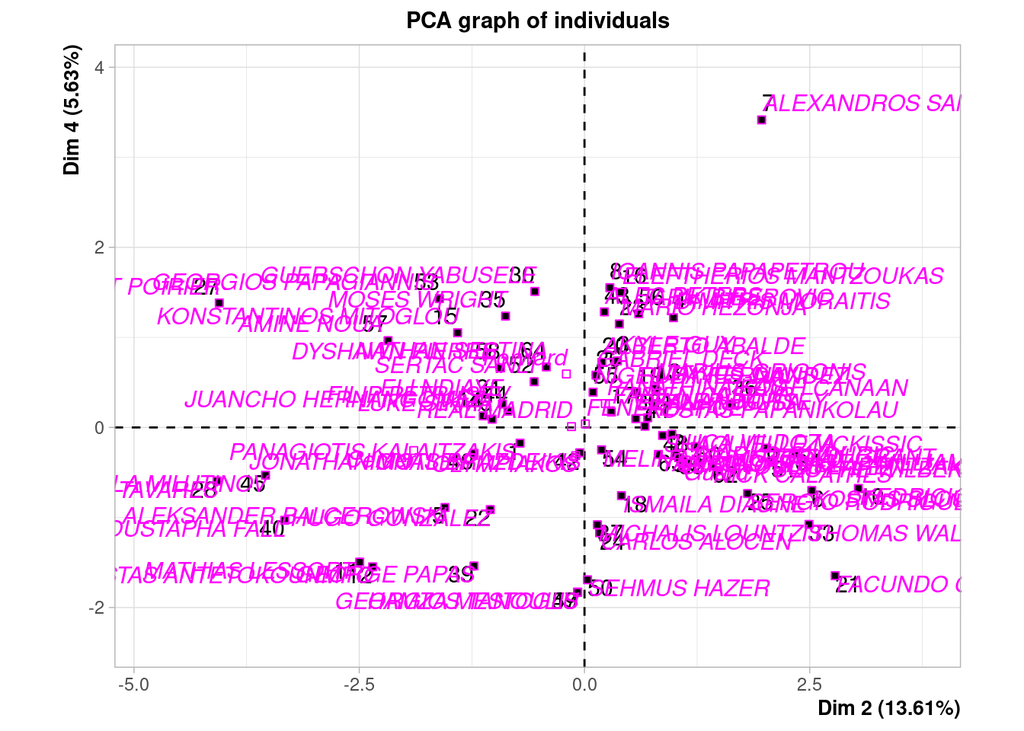

```r
plot.PCA(res_pca, choix="ind", axes=c(2, 4), main="Dim 2 vs Dim 4")
```

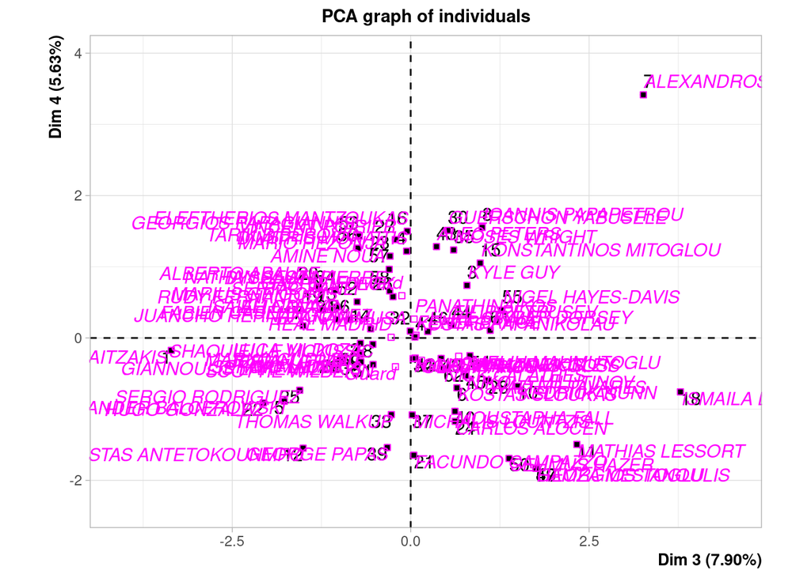

```r
# Finally, Dim 3 vs Dim 4
plot.PCA(res_pca, choix="ind", axes=c(3, 4), main="Dim 3 vs Dim 4")
```